# Feauture Selection

Faith Rotich

2/4/2022

# Wk 14 IP - FEATURE SELECTION

1. DEFINING THE QUESTION
2. METRICS OF SUCCESS
3. EXPERIMENTAL DESIGN
4. IMPLEMENTING THE SOLUTION
5. CHALLENING THE SOLUTION
6. CONCLUSION AND RECOMMENDATION
7. DEFING THE QUESTION
1. Problem Statement

You are a Data analyst at Carrefour Kenya and are currently undertaking a project that will inform the marketing department on the most relevant marketing strategies that will result in the highest no. of sales (total price including tax). Your project has been divided into four parts where you’ll explore a recent marketing dataset by performing various unsupervised learning techniques and later providing recommendations based on your insights.

Part 2: Feature Selection

This section requires you to perform feature selection through the use of the unsupervised learning methods learned earlier this week. You will be required to perform your analysis and provide insights on the features that contribute the most information to the dataset.

2. METRICS OF SUCCESS
- Successfully carrying out feature selection using unsupervised learning algorithms

# 1. Loading the libraries

```r
# Loading the library

library(caret)
```

```r
library(corrplot)
library(data.table)
library(tidyverse)
library(dplyr)
```

# 2. Reading and Viewing the data

```r
# Reading the data
data <- fread("http://bit.ly/CarreFourDataset")
```

```r
# Viewing the first 5 rows
head(data)
```

```
##     Invoice ID Branch Customer type Gender           Product line Unit price
## 1: 750-67-8428      A        Member Female      Health and beauty      74.69
## 2: 226-31-3081      C        Normal Female Electronic accessories      15.28
## 3: 631-41-3108      A        Normal   Male     Home and lifestyle      46.33
## 4: 123-19-1176      A        Member   Male      Health and beauty      58.22
## 5: 373-73-7910      A        Normal   Male      Sports and travel      86.31
## 6: 699-14-3026      C        Normal   Male Electronic accessories      85.39
##    Quantity     Tax      Date  Time     Payment   cogs gross margin percentage
## 1:        7 26.1415  1/5/2019 13:08     Ewallet 522.83                4.761905
## 2:        5  3.8200  3/8/2019 10:29        Cash  76.40                4.761905
## 3:        7 16.2155  3/3/2019 13:23 Credit card 324.31                4.761905
## 4:        8 23.2880 1/27/2019 20:33     Ewallet 465.76                4.761905
## 5:        7 30.2085  2/8/2019 10:37     Ewallet 604.17                4.761905
## 6:        7 29.8865 3/25/2019 18:30     Ewallet 597.73                4.761905
##    gross income Rating    Total
## 1:      26.1415    9.1 548.9715
## 2:       3.8200    9.6  80.2200
## 3:      16.2155    7.4 340.5255
## 4:      23.2880    8.4 489.0480
## 5:      30.2085    5.3 634.3785
## 6:      29.8865    4.1 627.6165
```

```r
# Viewing the last 5 rows
tail(data)
```

```
##     Invoice ID Branch Customer type Gender           Product line Unit price
## 1: 652-49-6720      C        Member Female Electronic accessories      60.95
## 2: 233-67-5758      C        Normal   Male      Health and beauty      40.35
## 3: 303-96-2227      B        Normal Female     Home and lifestyle      97.38
## 4: 727-02-1313      A        Member   Male     Food and beverages      31.84
## 5: 347-56-2442      A        Normal   Male     Home and lifestyle      65.82
## 6: 849-09-3807      A        Member Female    Fashion accessories      88.34
##    Quantity     Tax      Date  Time Payment   cogs gross margin percentage
## 1:        1  3.0475 2/18/2019 11:40 Ewallet  60.95                4.761905
## 2:        1  2.0175 1/29/2019 13:46 Ewallet  40.35                4.761905
## 3:       10 48.6900  3/2/2019 17:16 Ewallet 973.80                4.761905
## 4:        1  1.5920  2/9/2019 13:22    Cash  31.84                4.761905
## 5:        1  3.2910 2/22/2019 15:33    Cash  65.82                4.761905
## 6:        7 30.9190 2/18/2019 13:28    Cash 618.38                4.761905
##    gross income Rating     Total
## 1:       3.0475    5.9   63.9975
## 2:       2.0175    6.2   42.3675
## 3:      48.6900    4.4 1022.4900
## 4:       1.5920    7.7   33.4320
## 5:       3.2910    4.1   69.1110
## 6:      30.9190    6.6  649.2990
```

```r
# Viewing the size of the data
dim(data)
```

```
## [1] 1000   16
```

```r
# Statistical Summary

summary(data)
```

```
##   Invoice ID           Branch          Customer type         Gender
##  Length:1000        Length:1000        Length:1000        Length:1000
##  Class :character   Class :character   Class :character   Class :character
##  Mode  :character   Mode  :character   Mode  :character   Mode  :character
##
##
##
##  Product line         Unit price       Quantity          Tax
##  Length:1000        Min.   :10.08   Min.   : 1.00   Min.   : 0.5085
##  Class :character   1st Qu.:32.88   1st Qu.: 3.00   1st Qu.: 5.9249
##  Mode  :character   Median :55.23   Median : 5.00   Median :12.0880
##                     Mean   :55.67   Mean   : 5.51   Mean   :15.3794
##                     3rd Qu.:77.94   3rd Qu.: 8.00   3rd Qu.:22.4453
##                     Max.   :99.96   Max.   :10.00   Max.   :49.6500
##      Date               Time             Payment               cogs
##  Length:1000        Length:1000        Length:1000        Min.   : 10.17
##  Class :character   Class :character   Class :character   1st Qu.:118.50
##  Mode  :character   Mode  :character   Mode  :character   Median :241.76
##                                                           Mean   :307.59
##                                                           3rd Qu.:448.90
##                                                           Max.   :993.00
##  gross margin percentage  gross income         Rating           Total
##  Min.   :4.762           Min.   : 0.5085   Min.   : 4.000   Min.   :  10.68
##  1st Qu.:4.762           1st Qu.: 5.9249   1st Qu.: 5.500   1st Qu.: 124.42
##  Median :4.762           Median :12.0880   Median : 7.000   Median : 253.85
##  Mean   :4.762           Mean   :15.3794   Mean   : 6.973   Mean   : 322.97
##  3rd Qu.:4.762           3rd Qu.:22.4453   3rd Qu.: 8.500   3rd Qu.: 471.35
##  Max.   :4.762           Max.   :49.6500   Max.   :10.000   Max.   :1042.65
```

```r
# Checking data types
sapply(data, class)
```

```
##              Invoice ID                  Branch           Customer type
##             "character"             "character"             "character"
##                  Gender            Product line              Unit price
##             "character"             "character"               "numeric"
##                Quantity                     Tax                    Date
##               "integer"               "numeric"             "character"
##                    Time                 Payment                    cogs
##             "character"             "character"               "numeric"
## gross margin percentage            gross income                  Rating
##               "numeric"               "numeric"               "numeric"
##                   Total
##               "numeric"
```

# 3. Data Cleaning

```r
# Checking for missing values

colSums(is.na(data))
```

```
##              Invoice ID                  Branch           Customer type
##                       0                       0                       0
##                  Gender            Product line              Unit price
##                       0                       0                       0
##                Quantity                     Tax                    Date
##                       0                       0                       0
##                    Time                 Payment                    cogs
##                       0                       0                       0
## gross margin percentage            gross income                  Rating
##                       0                       0                       0
##                   Total
##                       0
```

There are no missing values in the data

```r
#Checking for Duplicates
duplicated_rows <- data[duplicated(data),]

duplicated_rows
```

```
## Empty data.table (0 rows and 16 cols): Invoice ID,Branch,Customer type,Gender,Product line,Unit price...
```

There are no duplicated rows

```r
# showing these unique items and assigning to a variable unique_items below
unique_items <- data[!duplicated(data), ]
unique_items
```

```
##        Invoice ID Branch Customer type Gender           Product line Unit price
##    1: 750-67-8428      A        Member Female      Health and beauty      74.69
##    2: 226-31-3081      C        Normal Female Electronic accessories      15.28
##    3: 631-41-3108      A        Normal   Male     Home and lifestyle      46.33
##    4: 123-19-1176      A        Member   Male      Health and beauty      58.22
##    5: 373-73-7910      A        Normal   Male      Sports and travel      86.31
##   ---
##  996: 233-67-5758      C        Normal   Male      Health and beauty      40.35
##  997: 303-96-2227      B        Normal Female     Home and lifestyle      97.38
##  998: 727-02-1313      A        Member   Male     Food and beverages      31.84
##  999: 347-56-2442      A        Normal   Male     Home and lifestyle      65.82
## 1000: 849-09-3807      A        Member Female    Fashion accessories      88.34
##       Quantity     Tax      Date  Time     Payment   cogs
##    1:        7 26.1415  1/5/2019 13:08     Ewallet 522.83
##    2:        5  3.8200  3/8/2019 10:29        Cash  76.40
```

[output cut: 21 more lines]

```r
# selecting the numerical data columns
df <- data %>% select_if(is.numeric)


# selecting needed columns
df1 <- subset(df, select = c("Unit price", "Quantity", "Tax", "cogs", "gross income", "Rating", "Total"))
colnames(df1)
```

```
## [1] "Unit price"   "Quantity"     "Tax"          "cogs"         "gross income"
## [6] "Rating"       "Total"
```

# Feature Selection in Unsupervised Learning

## Using filter methods

```r
colnames(df1)
```

```
## [1] "Unit price"   "Quantity"     "Tax"          "cogs"         "gross income"
## [6] "Rating"       "Total"
```

```r
# Calculating the correlation matrix
correlationMatrix <- cor(df1)


# Find attributes that are highly correlated
highlyCorrelated <- findCorrelation(correlationMatrix, cutoff=0.75)
highlyCorrelated
```

```
## [1] 4 7 3
```

Columns 4,7 and 3 are highly correlated

```r
# Removing Redundant Features
df2<-df1[-highlyCorrelated]
```

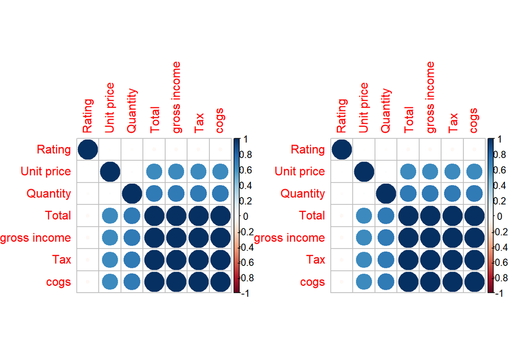

```r
# Performing our graphical comparison
par(mfrow = c(1, 2))
corrplot(correlationMatrix, order = "hclust")
corrplot(cor(df2), order = "hclust")
```

# Numericals

```r
library("dplyr")
numerical<-select_if(df1,is.numeric)
numerical
```

```
##       Unit price Quantity     Tax   cogs gross income Rating     Total
##    1:      74.69        7 26.1415 522.83      26.1415    9.1  548.9715
##    2:      15.28        5  3.8200  76.40       3.8200    9.6   80.2200
##    3:      46.33        7 16.2155 324.31      16.2155    7.4  340.5255
##    4:      58.22        8 23.2880 465.76      23.2880    8.4  489.0480
##    5:      86.31        7 30.2085 604.17      30.2085    5.3  634.3785
##   ---
##  996:      40.35        1  2.0175  40.35       2.0175    6.2   42.3675
##  997:      97.38       10 48.6900 973.80      48.6900    4.4 1022.4900
##  998:      31.84        1  1.5920  31.84       1.5920    7.7   33.4320
##  999:      65.82        1  3.2910  65.82       3.2910    4.1   69.1110
## 1000:      88.34        7 30.9190 618.38      30.9190    6.6  649.2990
```

```r
# Selecting non numeric columns
head(df1)
```

```
##    Unit price Quantity     Tax   cogs gross income Rating    Total
## 1:      74.69        7 26.1415 522.83      26.1415    9.1 548.9715
## 2:      15.28        5  3.8200  76.40       3.8200    9.6  80.2200
## 3:      46.33        7 16.2155 324.31      16.2155    7.4 340.5255
## 4:      58.22        8 23.2880 465.76      23.2880    8.4 489.0480
## 5:      86.31        7 30.2085 604.17      30.2085    5.3 634.3785
## 6:      85.39        7 29.8865 597.73      29.8865    4.1 627.6165
```

```r
# Caret package for dummy variables
library(caret)
# Encoding using Dummy variables and excluding unique ID and date time data
dums<-dummyVars("~.",data=df1[,c(-1,-9,-10)])
dums
```

```
## Dummy Variable Object
##
## Formula: ~.
## <environment: 0x00000000256413c8>
## 6 variables, 0 factors
## Variables and levels will be separated by '.'
## A less than full rank encoding is used
```

```r
# Encoding.
new_df<-data.frame(predict(dums,newdata =df1[,c(-1,-9,-10)]))
new_df
```

```
##      Quantity     Tax   cogs X.gross.income. Rating     Total
## 1           7 26.1415 522.83         26.1415    9.1  548.9715
## 2           5  3.8200  76.40          3.8200    9.6   80.2200
## 3           7 16.2155 324.31         16.2155    7.4  340.5255
## 4           8 23.2880 465.76         23.2880    8.4  489.0480
## 5           7 30.2085 604.17         30.2085    5.3  634.3785
## 6           7 29.8865 597.73         29.8865    4.1  627.6165
## 7           6 20.6520 413.04         20.6520    5.8  433.6920
## 8          10 36.7800 735.60         36.7800    8.0  772.3800
## 9           2  3.6260  72.52          3.6260    7.2   76.1460
## 10          3  8.2260 164.52          8.2260    5.9  172.7460
## 11          4  2.8960  57.92          2.8960    4.5   60.8160
## 12          4  5.1020 102.04          5.1020    6.8  107.1420
## 13          5 11.7375 234.75         11.7375    7.1  246.4875
## 14         10 21.5950 431.90         21.5950    8.2  453.4950
```

[output cut: 986 more lines]

```r
# Dimensionality Reduction technique
# Will use PCA so as to understand the variance displayed by each feature
reduced_df<-prcomp(new_df,center = TRUE)
# Since prcomp uses single value decomposition that tests each points covariance and correlation to each other.
```

```r
# Using the Standard Scalar of reduced_df

df1 = scale(df1)
```

```r
reduced_df$sdev
```

```
## [1] 3.399657e+02 2.072240e+00 1.716903e+00 4.629403e-14 2.840508e-15
## [6] 1.373381e-15
```

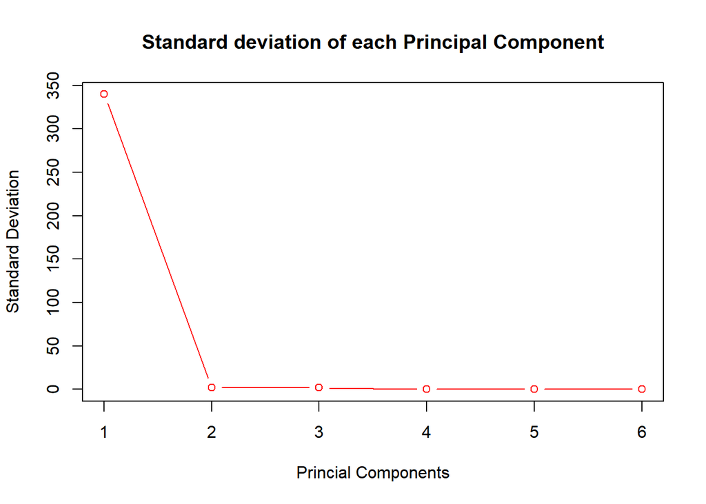

```r
# Checking the standard deviation of each PC
plot(reduced_df$sdev,main="Standard deviation of each Principal Component",ylab = "Standard Deviation",xlab = "Princial Components",type = "bar",col="red")
```

```r
# install.packages("factoextra")
```

```r
library(factoextra)
# Getting the sum of square distances from the projected point in our data


eigen_values<-get_eigenvalue(reduced_df)
eigen_values
```

```
##         eigenvalue variance.percent cumulative.variance.percent
## Dim.1 1.155767e+05     9.999373e+01                    99.99373
## Dim.2 4.294179e+00     3.715204e-03                    99.99745
## Dim.3 2.947758e+00     2.550318e-03                   100.00000
## Dim.4 2.143138e-27     1.854183e-30                   100.00000
## Dim.5 8.068486e-30     6.980629e-33                   100.00000
## Dim.6 1.886175e-30     1.631866e-33                   100.00000
```

PCA 1 also indicated by Dim.1 shows that it explaind 99.9% variance in the data however this is may not be an accurate result